# Appendix 6: Example uncertainty calculation

**2.** Convert the string into an simple features object:

```r
fields <- st_read(fields_string)
```

**3.** Initialize a list for storing results:

```r
fields_sim <- vector("list", length = dim(fields)[1])
```

**4.** Apply the simulation function to each field:

```r
for (i in 1:length(fields_sim)){

   fields_sim[[i]] <- simulate_soc(polygon=fields[i,])

}
```

For each iteration, the `simulate_soc` function is called with the i-th field as input. The result of `simulate_soc` is assigned to the i-th position in the `fields_sim` list. Every element of the list contains four objects.

- `soc_stock` is a SpatRaster object that contains true values of SOC stock in units of tons of SOC / hectare
- `soc_stock_hat` is a SpatRaster object that contains predicted values of SOC stock in units of tons of SOC / hectare (analogous to predictions from a digital soil mapping model)
- `soc_stock_error` a SpatRaster object that contains `soc_stock_hat` - `soc_stock`
- `sigma` is a SpatRaster object that contains the predictive standard deviation

The plot below shows the geostatistical simulation for one field of 320 acres.

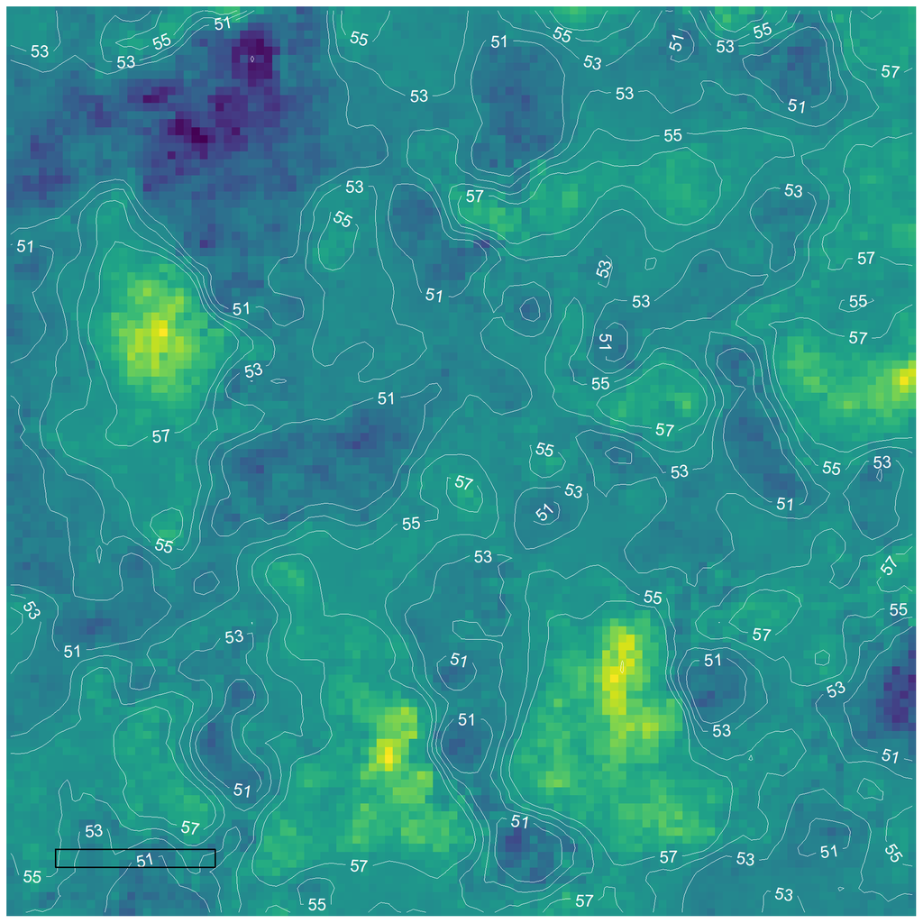

**Figure 1:** Example geostatistical simulation of SOC stock for a single 320 acre field. The scale bar in the lower left is 200 meters. Colors are the values of SOC stock in each pixel (prediction support unit), where warmer colors correspond to larger values. Contour intervals show SOC stock in tons / hectare to a depth of 30 cm. Every pixel in this image is a 10 by 10 meter square. The value represented by each pixel is $( \widehat{\text{SOC}}_{i,t})$, which appears in Equations 1 and 3 in the main text.

**IV. Fit a variogram to the standardized prediction error**

```r
set.seed(1)

# step 1

n_fields <- 10
n_samples <- 1000

# step 2

sample_index <- sample(seq(1:dim(fields)[1]), n_fields, replace=F)
area <- sum(st_area(fields[sample_index,]))
points_per_field <- as.numeric(round(1.1*n_samples * (st_area(fields[sample_index,1]) / area)))

# step 3

sampled_points_list <- vector("list", length = n_fields)

# step 4

for (i in 1:n_fields){

   sampled_points_list[[i]] <-st_sample(fields[sample_index[i],], size = points_per_field[i], type = "random")

}

# step 5

results_list <- vector("list", length = n_fields)

for (i in 1:n_fields){

   error <- terra::extract(fields_sim[[sample_index[i]]]$soc_stock_error, terra::vect(sampled_points_list[[i]]))[,2]
   sigma <- terra::extract(fields_sim[[sample_index[i]]]$sigma, terra::vect(sampled_points_list[[i]]))[,2]

   coords <- st_coordinates(sampled_points_list[[i]])

   df <- data.frame(
     error = error,
     sigma = sigma,
     x = coords[, 1],
     y = coords[, 2]
   )

   results_list[[i]] <- na.omit(df)

}

# step 6

error_data <- do.call(rbind, results_list)
error_data <- error_data[sample(seq(1,dim(error_data)[1],1), n_samples, replace=F),]

# step 7

error_data$spe <- error_data$error/error_data$sigma

# step 8

variogram_model <- variogram(spe~1, data=error_data, locations = ~ x + y, cutoff=1000)
vgm_model_exp <- fit.variogram(variogram_model, vgm("Exp"))
vgm_model_sph <- fit.variogram(variogram_model, vgm("Sph"))
vgm_model_nugget <- fit.variogram(variogram_model, vgm("Nug"))

#step 9

sph_variogram <- function(h, psill, range, nugget){

   ifelse(h <= range,
                   nugget + psill * ((3 * h) / (2 * range) - (h^3) / (2 * range^3)),
                   nugget + psill)

}

exp_variogram <- function(h, psill, range, nugget){

   nugget + psill * (1 - exp(-h / range))

}

SSE_sph <- sum(sph_variogram(h=variogram_model$dist, psill=vgm_model_sph[2,2],
                             range=vgm_model_sph[2,3], nugget =vgm_model_sph[1,2]) - variogram_model$gamma)^2
SSE_exp <- sum(exp_variogram(h=variogram_model$dist, psill=vgm_model_exp[2,2],
                             range=vgm_model_exp[2,3], nugget =vgm_model_exp[1,2]) - variogram_model$gamma)^2
SSE_nugget <- sum(vgm_model_nugget[1,2] - variogram_model$gamma)^2
```

**Steps in the code:**

**1.** Define the number of fields to be sampled and the total number of samples to be collected:

```r
n_fields <- 10
n_samples <- 1000
```

The number of fields to be sampled is given by `n_fields`, and the total number of samples to be collected is `n_samples`. These values can be modified. The numbers selected here indicate that out of the 100 fields in this hypothetical project, 10 will be randomly selected for sampling.

**2.** Randomly sample `n_fields` fields and allocate sampling effort:

```r
sample_index <- sample(seq(1:dim(fields)[1]), n_fields, replace=F)
area <- sum(st_area(fields[sample_index,]))
points_per_field <- as.numeric(round(1.1*n_samples * (st_area(fields[sample_index,1]) / area)))
```

`sample_index` is a vector of length `n_fields` that indexes fields at random for sampling. `area` is the summed area of the `n_fields` fields. `points_per_field` is the number of points to be randomly sampled within each field. Here this number is proportional to the area of each field. For example, if there were three fields to be sampled whose areas were 320, 320 and 160 acres, and if the total number of samples to be collected were 1,000, then the function would allocate 400, 400 and 200 samples to these fields, respectively, since they represent 40%, 40% and 20% of the summed area. Note that the sample number is increased by 10% to account for the possibility that some samples will happen to land on an edge that is inside the field boundary but not within a pixel. See step 4 below for an illustration of how these cases are handled to ensure that exactly `n_samples` are used.

**3.** Initialize a list for storing results:

```r
sampled_points_list <- vector("list", length = n_fields)
```

The list`sampled_points_list` is initialized as an empty list of length `n_fields`

**4.** Generate the sample locations within each field:

```r
for (i in 1:n_fields){

   sampled_points_list[[i]] <-st_sample(fields[sample_index[i],], size = points_per_field[i], type = "random")

}
```

This step iterates over every sampled field and randomly selects a number of points within each field. The number of points to be selected is given by `points_per_field`, computed in step 2, above.